# Project 1 Report: New York City Subway Ridership: An Analysis of the Week of September 15-21, 2024

Savannah Sauers, Lera Martinez, Simon Tao

2026-10-18

# Introduction

New York City has the largest subway system in the United States, and it serves as an essential part of the city’s public infrastructure. There are many benefits to widespread public transportation systems, but maximizing their effectiveness requires an understanding of how people use public transit in their everyday lives.

This exploration and analysis specifically examines New York City’s subway ridership in Manhattan, Brooklyn, the Bronx, and Queens during the week of September 15-21, 2024. This specific week was chosen because we felt it was likely going to be the best representation of a relatively normal week, meaning there are no holidays, school is in session, and it is not off season.

Specifically, we proposed the following three questions: - “How do NYC subway ridership volumes vary throughout the day?” - “Which hours have the highest ridership average (weekdays vs. weekends)?” - “Do these hours correspond to commuting periods?”

```r
library(tidyverse)
library(ezids)
library(car)
#project <- read.csv("~/Desktop/Fall 2026/DATS6101/DATS6101_Project_MTA_Subway_Hourly_Ridership.csv")
project <- read.csv("~/Desktop/Cloning-Git/DATS6101-project1/DATS6101_Project_MTA_Subway_Hourly_Ridership.csv")
```

# Data Source and Description

This project uses an hourly NYC subway ridership dataset published by the Metropolitan Transportation Authority (MTA) during the full seven-day week of September 15–21, 2024 ($N = 553,429$ observations). The dataset was obtained from https://data.ny.gov/Transportation/MTA-Subway-Hourly-Ridership-2020-2024/wujg-7c2s/about_data.

Our area of focus is: Subway ridership in four boroughs: Bronx, Brooklyn, Manhattan, and Queens.

Data Collection Method: Passenger entries were recorded automatically via turnstile swipes (MetroCard) and contactless taps (OMNY) at 424 station complexes across Manhattan, Brooklyn, Queens, and the Bronx

Data cleaned to remove duplication and uses on partner agencies (PATH, etc).

Time-late data due to malfunctioning hardware is incorporated as made available.

**Main Variables of Analysis**

These are the following main variables of analysis that we will be using from the original MTA dataset.

[output not shown]

# Data Quality and Cleaning

For the data cleaning portion, we first converted all the variables to either numeric or factor. We also checked for any NA values as well as duplicates. There were none for either of these, which ordinarily could have been suspicious, however considering that this data was cleaned by the MTA prior to having been uploaded for public downloads, we interpreted this more as a testament to the MTA’s strengths.

```r
# Make sure columns are cast to correct types
project$borough <- as.factor(project$borough)
project$payment_method <- as.factor(project$payment_method)
project$fare_class_category <- as.factor(project$fare_class_category)
project$ridership <- as.numeric(gsub(",", "", project$ridership))
project$transfers <- as.numeric(gsub(",", "", project$transfers))

# Checking for any NA values
colSums(is.na(project))
```

```
##   transit_timestamp        transit_mode  station_complex_id     station_complex
##                   0                   0                   0                   0
##             borough      payment_method fare_class_category           ridership
##                   0                   0                   0                   0
##           transfers            latitude           longitude        Georeference
##                   0                   0                   0                   0
```

```r
# Checking for duplicates
sum(duplicated(project))
```

```
## [1] 0
```

```r
str(project)
```

```
## 'data.frame':    553429 obs. of  12 variables:
##  $ transit_timestamp  : chr  "09/15/2024 12:00:00 AM" "09/15/2024 12:00:00 AM" "09/15/2024 12:00:00 AM" "09/15/2024 12:00:00 AM" ...
##  $ transit_mode       : chr  "subway" "subway" "subway" "subway" ...
##  $ station_complex_id : int  74 260 375 376 224 220 301 397 180 83 ...
##  $ station_complex    : chr  "18 Av (N)" "75 Av (E,F)" "Cypress Av (6)" "Brook Av (6)" ...
##  $ borough            : Factor w/ 4 levels "Bronx","Brooklyn",..: 2 4 1 1 3 3 3 3 2 4 ...
##  $ payment_method     : Factor w/ 2 levels "metrocard","omny": 2 2 2 2 2 1 2 1 1 1 ...
##  $ fare_class_category: Factor w/ 12 levels "Metrocard - Fair Fare",..: 12 9 9 9 12 6 9 6 1 2 ...
##  $ ridership          : num  1 6 4 1 6 1 20 25 3 6 ...
##  $ transfers          : num  0 0 0 0 0 0 0 0 0 0 ...
##  $ latitude           : num  40.6 40.7 40.8 40.8 40.8 ...
##  $ longitude          : num  -74 -73.8 -73.9 -73.9 -74 ...
##  $ Georeference       : chr  "POINT (-73.99042 40.62067)" "POINT (-73.837326 40.71833)" "POINT (-73.91404 40.805367)" "POINT (-73.91924 40.807568)" ...
```

```r
# Checking for any negative values to make sure there were no stragglers in the data cleaning
sum(project$ridership < 0, na.rm = TRUE)
```

```
## [1] 0
```

```r
sum(project$transfers < 0, na.rm = TRUE)
```

```
## [1] 0
```

```r
## Created Variables of Analysis
# Add 24-hour time column
project <- project %>%
  mutate(
    timestamp = mdy_hms(transit_timestamp),
    hour = hour(timestamp)
  )

# Add categories for morning, afternoon, evening, night
# Morning (5am - 10:59am), afternoon (11am - 3:59pm), evening (4pm - 8:59pm), night (9pm - 4:59am)
project <- project %>%
  mutate(
    time_of_day = case_when(
      hour >= 5 & hour < 11 ~ "Morning",
      hour >= 11 & hour < 16 ~ "Mid Day",
      hour >= 16 & hour < 21 ~ "Evening",
      TRUE ~ "Night"
    )
  )

# Add day of week column
project <- project %>%
  mutate(
    day_of_week = wday(timestamp, label = TRUE)
  )

# Weekend vs. Weekday column
project <- project %>%
  mutate(day_type = if_else(day_of_week %in% c("Sat", "Sun"), "Weekend", "Weekday"))

# Commuter hours column
project <- project %>%
  mutate(
    commute_type = case_when(
      day_type == "Weekday" & hour >= 5 & hour < 11 ~ "Morning Commute",
      day_type == "Weekday" & hour >= 16 & hour < 21 ~ "Evening Commute",
      TRUE ~ "Other Hours"
    )
  )

project$time_of_day <- as.factor(project$time_of_day)
project$day_of_week <- as.factor(project$day_of_week)
project$day_type <- as.factor(project$day_type)
project$commute_type <- as.factor(project$commute_type)
```

# Exploratory Data Analysis

The EDA had three main analytic goals, to identify patterns across:

- Time: Which hours/time periods have highest ridership
- Days: Weekday/Weekend comparison, commuting periods
- Geography: Ridership by borough and high bus-to-subway transfers

**Descriptive Statistics**

```r
xkablesummary (project, title = "Summary Statistics for Project")
```

Summary Statistics for Project

|  | transit_timestamp | transit_mode | station_complex_id | station_complex | borough | payment_method | fare_class_category | ridership | transfers | latitude | longitude | Georeference | timestamp | hour | time_of_day | day_of_week | day_type | commute_type |
| --- | --- | --- | --- | --- | --- | --- | --- | --- | --- | --- | --- | --- | --- | --- | --- | --- | --- | --- |
| Min | Length :553429 | Length :553429 | Min. : 1.0 | Length :553429 | Bronx : 88162 | metrocard:371260 | OMNY - Full Fare : 68758 | Min. : 1.00 | Min. : 0.000 | Min. :40.58 | Min. :-74.03 | Length :553429 | Min. :2024-09-15 00:00:00 | Min. : 0.00 | Evening:129705 | Sun:72335 | Weekday:403722 | Evening Commute: 94670 |
| Q1 | N.unique : 168 | N.unique : 1 | 1st Qu.:137.0 | N.unique : 424 | Brooklyn :196976 | omny :182169 | Metrocard - Full Fare : 65844 | 1st Qu.: 3.00 | 1st Qu.: 0.000 | 1st Qu.:40.68 | 1st Qu.:-73.98 | N.unique : 483 | 1st Qu.:2024-09-16 19:00:00 | 1st Qu.: 7.00 | Mid Day:133825 | Mon:80108 | Weekend:149707 | Morning Commute:113537 |
| Median | N.blank : 0 | N.blank : 0 | Median :269.0 | N.blank : 0 | Manhattan:169958 | NA | Metrocard - Unlimited 7-Day : 65222 | Median : 10.00 | Median : 0.000 | Median :40.73 | Median :-73.95 | N.blank : 0 | Median :2024-09-18 13:00:00 | Median :12.00 | Morning:152749 | Tue:80462 | NA | Other Hours :345222 |
| Mean | Min.nchar: 22 | Min.nchar: 6 | Mean :275.2 | Min.nchar: 8 | Queens : 98333 | NA | Metrocard - Unlimited 30-Day: 62958 | Mean : 46.18 | Mean : 1.582 | Mean :40.73 | Mean :-73.93 | Min.nchar: 22 | Mean :2024-09-18 13:06:22 | Mean :12.31 | Night :137150 | Wed:80688 | NA | NA |
| Q3 | Max.nchar: 22 | Max.nchar: 6 | 3rd Qu.:388.0 | Max.nchar: 55 | NA | NA | Metrocard - Other : 62191 | 3rd Qu.: 30.00 | 3rd Qu.: 0.000 | 3rd Qu.:40.80 | 3rd Qu.:-73.90 | Max.nchar: 28 | 3rd Qu.:2024-09-20 07:00:00 | 3rd Qu.:18.00 | NA | Thu:81057 | NA | NA |
| Max | NA | NA | Max. :636.0 | NA | NA | NA | Metrocard - Fair Fare : 60378 | Max. :14012.00 | Max. :1350.000 | Max. :40.90 | Max. :-73.76 | NA | Max. :2024-09-21 23:00:00 | Max. :23.00 | NA | Fri:81407 | NA | NA |
| NA | NA | NA | NA | NA | NA | NA | (Other) :168078 | NA | NA | NA | NA | NA | NA | NA | NA | Sat:77372 | NA | NA |

```r
max_value_ridership <- project %>%
  arrange(desc(ridership))
```

This dataset contains 553,429 station-hour records across 424 station complexes in the four boroughs. The core numerical metrics evaluated are total ridership (station entries) and transfers (intermodal bus-to-subway entries, which represent a sub-category contained within total ridership). The maximum value of ridership is one to point out reaching 14012 taps, within one hour at one station, with a minimum of 1 a very striking spread.

```r
with_timestamp <- project %>%
  mutate(timestamp = mdy_hms(transit_timestamp))

observations_total <- with_timestamp %>%
  mutate(date = as.Date(timestamp)) %>%
  count(date, name = "number_of_observations") %>%
  arrange(date)

observations_total
```

```
##         date number_of_observations
## 1 2024-09-15                  72335
## 2 2024-09-16                  80108
## 3 2024-09-17                  80462
## 4 2024-09-18                  80688
## 5 2024-09-19                  81057
## 6 2024-09-20                  81407
## 7 2024-09-21                  77372
```

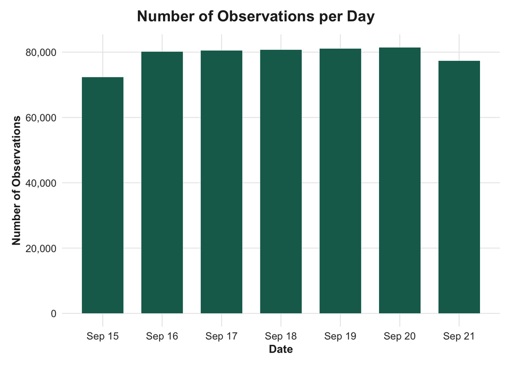

```r
# Bar chart
week_bar_chart_observations <- ggplot(observations_total, aes(x = date, y = number_of_observations)) +
  geom_col(fill = "#176B5B", width = 0.7) +
  scale_x_date(breaks = observations_total$date,date_labels = "%b %d")+ #To include all the dates on the x axis with the month and date
  scale_y_continuous(labels = scales::comma) +
  labs(
    title = "Number of Observations per Day",
    x = "Date",
    y = "Number of Observations"
  ) +

  theme_mygraphs()

week_bar_chart_observations
```

The number of observations recorded on each date was also examined to assess consistency in data coverage. Daily observation counts remain highly stable between ~72,000 (Sunday, Sept 15) and ~81,000 (weekdays).

This confirms balanced, uninterrupted data recording across all 168 temporal hours of the study window.

**Overall Patterns in Subway Ridership**

```r
# Week average for total ridership by borough
borough_ridership_means <- project %>%
  group_by(borough, transit_timestamp) %>%
  summarize(hourly_ridership = sum(ridership, na.rm=TRUE), .groups = "drop") %>%
  group_by(borough) %>%
  summarize(mean_week_ridership = mean(hourly_ridership, na.rm=TRUE))

borough_ridership_means
```

```
## # A tibble: 4 × 2
##   borough   mean_week_ridership
##   <fct>                   <dbl>
## 1 Bronx                  10521.
## 2 Brooklyn               34414.
## 3 Manhattan              84227.
## 4 Queens                 22971.
```

This shows the average number of riders in each borough per timestamp. Includes all stations and times of day. The greatest to least mean total ridership by borough: Manhattan, Brooklyn, Queens, Bronx.

```r
# Week average hourly ridership by station and borough
station_ridership_means <- project %>%
  group_by(borough, station_complex_id) %>%
  summarize(mean_ridership = mean(ridership, na.rm=TRUE)) %>%
  arrange(desc(mean_ridership))
```

[output not shown]

```r
station_ridership_means
```

```
## # A tibble: 424 × 3
## # Groups:   borough [4]
##    borough   station_complex_id mean_ridership
##    <fct>                  <int>          <dbl>
##  1 Manhattan                611           558.
##  2 Manhattan                610           429.
##  3 Manhattan                607           305.
##  4 Manhattan                602           302.
##  5 Manhattan                628           257.
##  6 Manhattan                614           232.
##  7 Manhattan                164           230.
##  8 Manhattan                318           211.
##  9 Queens                   447           195.
## 10 Queens                   616           190.
## # ℹ 414 more rows
```

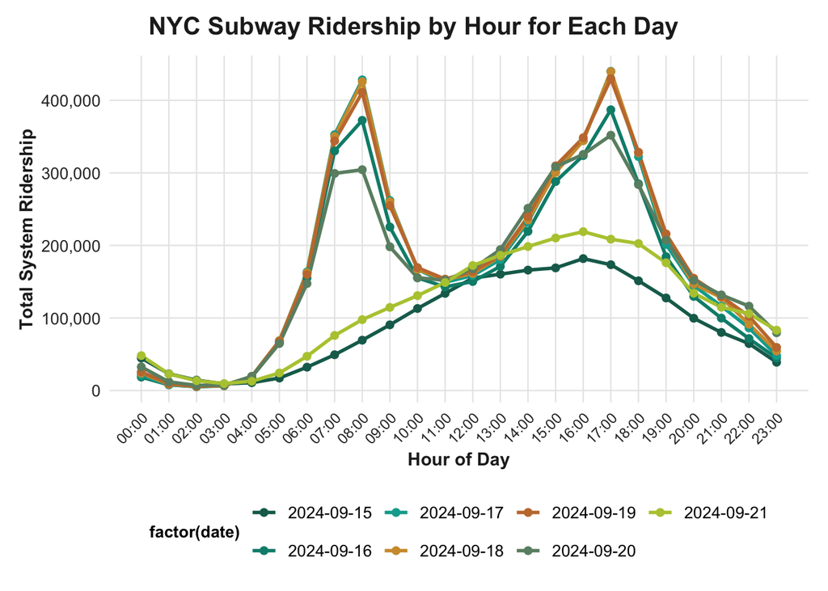

```r
project <- project %>%
  mutate(
    timestamp = mdy_hms(transit_timestamp),
    hour = hour(timestamp)
  )

#Sum of system ridership for each hour of each day
daily_hourly_ridership <- project %>%
  mutate(date = as.Date(timestamp)) %>%
  group_by(date, hour) %>%
  summarize(
    total_ridership = sum(ridership, na.rm = TRUE),
    .groups = "drop"
  )

#Line plot
ggplot(
  daily_hourly_ridership,
  aes(
    x = hour,
    y = total_ridership,
    color = factor(date),
    group = date
  )
) +
  geom_line(linewidth = 1) +
  geom_point(size = 1.8) +
  scale_x_continuous(
    breaks = 0:23, #To have all the hours displayed
    labels = sprintf("%02d:00", 0:23) #24 hour format
  ) +
  scale_y_continuous(labels = scales::comma) + #Adds commas to the numbers on the axis
scale_color_manual(
  values = c(
    "#176B5B",  # Dark teal
    "#008C7A",  # Teal
    "#00A99D",  # Turquoise
    "#D09A3A",  # Muted gold
    "#C47A3C",  # Light brown
    "#6B8E72",  # Sage
    "#B5C83E"   # Yellow green
  )
)+
  labs(
    title = "NYC Subway Ridership by Hour for Each Day",
    x = "Hour of Day",
    y = "Total System Ridership"
  ) +
  theme_mygraphs()+
  theme(
    axis.text.x = element_text(
      angle = 45,
      hjust = 1,
      vjust = 1,
      size = 9
    )
  )
```

Weekdays (Sept 16-20) display a pronounced bimodal commuting profile, characterized by a sharp morning rush peak at 08:00 AM (~400,000 riders) and an evening peak at 05:00 PM (>420,000 riders). Morning Peak: A steep climb from ~15,000 riders at 03:00 AM to a sharp peak between 300,000 and 420,000 riders at 08:00 AM. Midday Trough: A drop to ~150,000 riders around 11:00 AM–12:00 PM. Evening Peak: A second, even larger surge peaking between 350,000 and 430,000 riders at 05:00 PM (17:00). Late Night: Drops near zero (~10,000-20,000 riders) between 01:00 AM and 04:00 AM. In contrast, weekend curves (Sept 15 & Sept 21) exhibit smooth, flattened arcs peaking gently near ~200,000 riders at 04:00 PM.

The severe dip between rush-hour peaks and midday/overnight hours establishes the definition for commute (Weekday 5:00 AM-10:59 AM and 4:00 PM-8:59 PM). This directly motivated our future Two-Sample t-test.

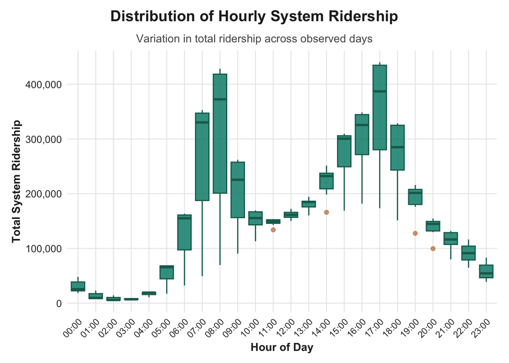

```r
ggplot(
  daily_hourly_ridership,
  aes(x = factor(hour), y = total_ridership)
) +
  geom_boxplot(
    fill = "#008C7A",
    color = "#176B5B",
    alpha = 0.85,
    outlier.color = "#C47A3C",
    outlier.alpha = 0.7
  ) +
  scale_y_continuous(labels = scales::comma) +
  scale_x_discrete(
    labels = sprintf("%02d:00", 0:23)
  ) +
  labs(
    title = "Distribution of Hourly System Ridership",
    subtitle = "Variation in total ridership across observed days",
    x = "Hour of Day",
    y = "Total System Ridership"
  ) +
  theme_mygraphs() +
  theme(
    axis.text.x = element_text(
      angle = 45,
      hjust = 1,
      size = 9
    )
  )
```

The non-uniform variance across hours motivates the future One-Way ANOVA across time periods analysis.

**Weekday and Weekend Comparisons**

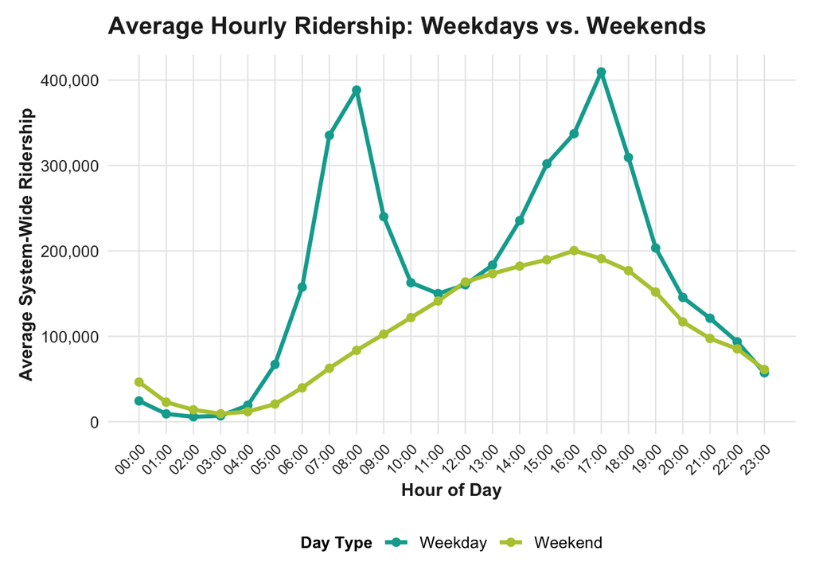

```r
#Sum ridership, then group for type of day, then average of every hour of those groups
average_by_day_type <- project %>%
  mutate(date = as.Date(timestamp)) %>%
  group_by(date, hour, day_type) %>%
  summarize(
    total_ridership = sum(ridership, na.rm = TRUE),
    .groups = "drop"
  ) %>%
  group_by(day_type, hour) %>%
  summarize(
    mean_ridership = mean(total_ridership, na.rm = TRUE),
    .groups = "drop"
  )

#Line graph
ggplot(
  average_by_day_type,
  aes(
    x = hour,
    y = mean_ridership,
    color = day_type,
    group = day_type
  )
) +
  geom_line(linewidth = 1.2) +
  geom_point(size = 2) +
  scale_color_manual(
    values = c(
      "Weekday" = "#00A99D",
      "Weekend" = "#B5C83E"
    )
  ) +
  scale_x_continuous(
    breaks = 0:23,
    labels = sprintf("%02d:00", 0:23)
  ) +
  scale_y_continuous(labels = scales::comma) +
  labs(
    title = "Average Hourly Ridership: Weekdays vs. Weekends",
    x = "Hour of Day",
    y = "Average System-Wide Ridership",
    color = "Day Type"
  ) +
  theme_mygraphs() +
  theme(
    axis.text.x = element_text(
      angle = 45,
      hjust = 1,
      vjust = 1,
      size = 9
    )
  )
```

The weekday line rises rapidly from ~10,000 at 03:00 AM to a morning peak of ~390,000 riders at 08:00 AM, dips to ~150,000 at midday, and reaches its maximum peak of ~410,000 riders at 05:00 PM (17:00). The weekend line climbs gradually from ~10,000 at 03:00 AM to a broad, flat plateau of ~200,000 riders between 03:00 PM and 05:00 PM, before gently tapering off.

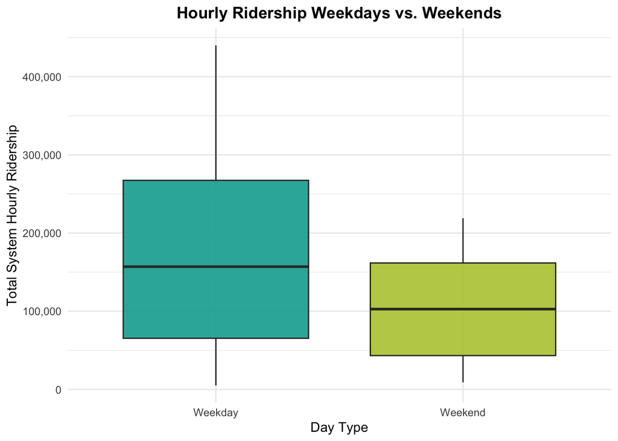

```r
system_hourly_day <- project %>%
  group_by(timestamp, day_type) %>%
  summarize(
    total_ridership = sum(ridership, na.rm = TRUE),
    .groups = "drop"
  )

#Plot
ggplot(system_hourly_day,
       aes(x = day_type, y = total_ridership, fill = day_type)) +
  geom_boxplot(alpha = 0.9) +
  scale_fill_manual(values = c("Weekday" = "#00A99D",
                               "Weekend" = "#B5C83E")) +
  scale_y_continuous(labels = scales::comma) +
  labs(
    title = "Hourly Ridership Weekdays vs. Weekends",
    x = "Day Type",
    y = "Total System Hourly Ridership"
  ) +
  theme_minimal() +
  theme(
    plot.title = element_text(face = "bold", hjust = 0.5),
    legend.position = "none"
  )
```

The weekday box is tall and wide, with an IQR spanning from ~65,000 to ~270,000 riders/hr, a solid horizontal median line at ~155,000 riders/hr, and an upper whisker reaching all the way to ~440,000 riders/hr. On the other hand, the weekend box is substantially shorter and lower, with an IQR spanning from ~45,000 to ~160,000 riders/hr, a median at ~100,000 riders/hr, and an upper whisker topping out near ~220,000 riders/hr.

These two graphs grounded the Two-Sample Weekday vs. Weekend t-test.

**Geographic Differences in Ridership**

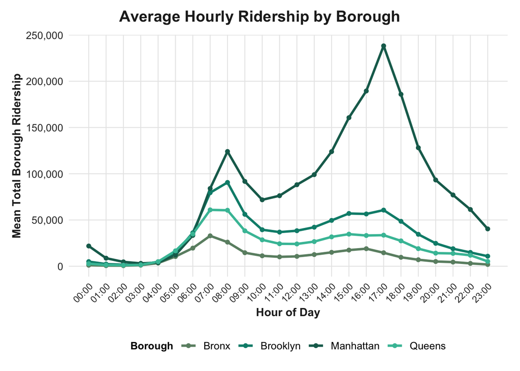

```r
borough_hourly <- project %>%
  group_by(borough, timestamp, hour) %>%
  summarize(
    total_ridership = sum(ridership, na.rm = TRUE),
    .groups = "drop"
  ) %>%
  group_by(borough, hour) %>%
  summarize(
    mean_ridership = mean(total_ridership, na.rm = TRUE),
    .groups = "drop"
  )

#Line graph
ggplot(borough_hourly,
       aes(x = hour, y = mean_ridership, color = borough)) +
  geom_line(linewidth = 1.1) +
  geom_point(size = 1.5) +
   scale_color_manual(
   values = c(
    "Bronx"     = "#6B8E72",
    "Brooklyn"  = "#008C7A",
    "Manhattan" = "#176B5B",
    "Queens"    = "#42BFA5" )
  ) +
  scale_x_continuous(
    breaks = 0:23,
    labels = sprintf("%02d:00", 0:23)
  ) +
  scale_y_continuous(labels = scales::comma) +
  labs(
    title = "Average Hourly Ridership by Borough",
    x = "Hour of Day",
    y = "Mean Total Borough Ridership",
    color = "Borough"
  ) +
  theme_mygraphs() +
  theme(
    axis.text.x = element_text(
      angle = 45,
      hjust = 1,
      vjust = 1,
      size = 9
    )
  )
```

From this graph we can see that while outer boroughs see some morning outbound peaks as residents head to work, Manhattan generates the majority of the system’s evening surge as commuters and visitors enter Manhattan turnstiles to head home

**Bus-to-Subway Transfers**

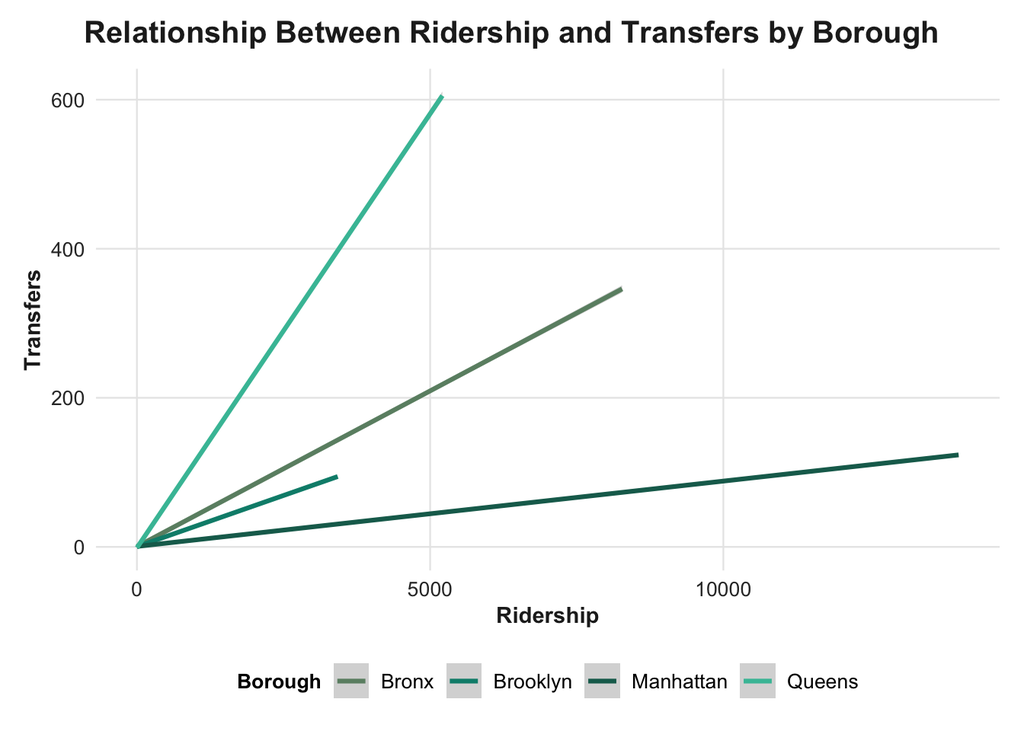

```r
scatter <- project %>%
  ggplot(aes(x=ridership, y=transfers, color=borough)) +
  geom_smooth(method = "lm") +
   scale_color_manual(
  values = c(
    "Bronx"     = "#6B8E72",
    "Brooklyn"  = "#008C7A",
    "Manhattan" = "#176B5B",
    "Queens"    = "#42BFA5" )
  ) +
  labs(
    title = "Relationship Between Ridership and Transfers by Borough",
    x = "Ridership",
    y = "Transfers",
    color = "Borough"
  ) +
  theme_mygraphs()


scatter
```

**Summary Statistics Station Ridership**

```r
#Station ridership
project %>%
  summarize(
    median = median(ridership, na.rm = TRUE),
    IQR = IQR(ridership, na.rm = TRUE),
    standard_deviation = sd(ridership, na.rm = TRUE),
    minimum = min(ridership, na.rm = TRUE),
    maximum = max(ridership, na.rm = TRUE)
  )
```

```
##   median IQR standard_deviation minimum maximum
## 1     10  27           187.4403       1   14012
```

With the Median of 10 riders/hour and IQR of 27 riders/hour, this means that half of all station-hour observations across the entire MTA network log 10 or fewer passenger entries per hour, so the middle 50% of all station-hour logs fall between 3 and 30 riders. The standard deviation (187.44) is over 18 times larger than the median (10). This massive spread confirms a right-skewed, heavy-tailed distribution. A vast majority of outer-borough neighborhood stations experience not very high entry volumes, while a small handful of massive Manhattan transit hubs handle very high passenger surges during commute hours.

**Summary Statistics Station Transfers**

```r
#Station transfers
project %>%
  summarize(
    median = median(transfers, na.rm = TRUE),
    IQR = IQR(transfers, na.rm = TRUE),
    standard_deviation = sd(transfers, na.rm = TRUE),
    minimum = min(transfers, na.rm = TRUE),
    maximum = max(transfers, na.rm = TRUE)
  )
```

```
##   median IQR standard_deviation minimum maximum
## 1      0   0           11.29689       0    1350
```

The striking numbers here are that the Median is 0 transfers/hour and as such the IQR is 0 transfers/hour, so at least 75% of all station-hour records in the entire system record exactly 0 bus-to-subway transfers. However, despite a median of zero, the maximum reaches 1,350 transfers in a single hour

Based on the preliminary EDA visual and descriptive metrics, the initial answers to the study’s core research questions can be summarized prior to formal hypothesis testing:

1. Temporal Patterns: Subway demand is structured by work-week routines, exhibiting a strong bimodal weekday commute profile that collapses on weekends into a low-volume, unimodal curve.
2. Geographic Distribution: Manhattan functions as the network’s volume hub, handling over twice the daily entry volume of any outer borough.
3. Infrastructure Focus: While Manhattan leads in total passenger count, Queens functions as the primary intermodal connection hub.

# Analysis and Interpretation

**Overview**

In order to further analyze the three questions of interest, four different statistical tests were performed on our dataset. These tests consisted of a two-sample t-test comparing mean hourly ridership in commute versus non-commute periods, a two-sample t-test comparing mean hourly ridership between weekdays and weekends, a one-way ANOVA that compares mean hourly ridership between different time-of-day categories (morning, midday, evening, and night), and a one-way ANOVA that compares mean daily ridership between the four boroughs in the dataset.

**Commute vs. Non-Commute t-test**

A two-sample t test was conducted to determine if there was a statistically significant difference between the mean hourly ridership during commute and non-commute periods. Commute periods were classified to be during the morning or evening, which falls between 5:00 AM - 10:59 AM and 4:00 PM - 9:00 PM in the context of this dataset. Non-commute periods were classified as midday and night periods, falling from 11:00 AM - 3:59 PM and 9:00 PM - 4:59 AM.

The null hypothesis for this test states that the mean hourly ridership during commute periods is equal to the mean hourly ridership during non-commute periods. The alternative hypothesis states that the mean hourly ridership during commute periods is different from the mean hourly ridership during non-commute periods. Before conducting this test, the assumptions were checked. We found that the population standard deviation was unknown given that we took a sample of the data and that the sample size is large enough per the central limit theorem to be robust against a normality violation. The independent observation may be violated due to our data being a time series set, but we continued with the two-sample t-test because it most closely fit the situation we are analyzing.

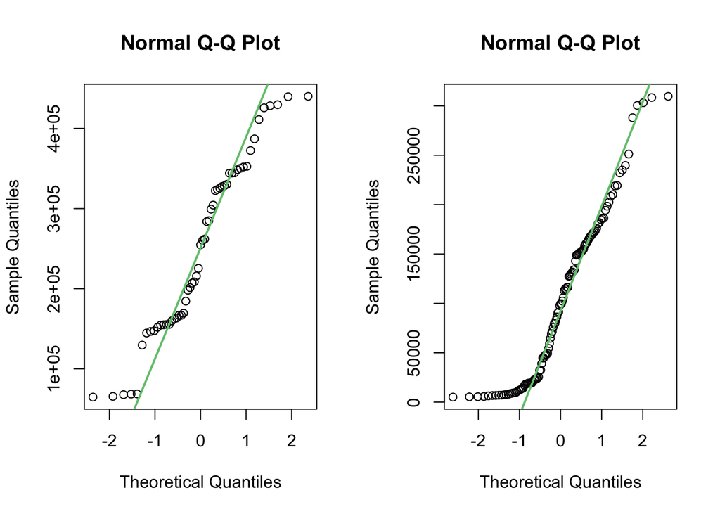

```r
hourly_ridership <- project %>%
  mutate(commute_period = if_else(commute_type %in% c("Morning Commute", "Evening Commute"), "Commute","Non-Commute")) %>%
  group_by(timestamp, day_type, time_of_day, commute_period) %>%
  summarize(total_ridership = sum(ridership, na.rm = TRUE), .groups = "drop")

par(mfrow = c(1, 2))
qqnorm(hourly_ridership$total_ridership[hourly_ridership$commute_period == "Commute"])
qqline(hourly_ridership$total_ridership[hourly_ridership$commute_period == "Commute"], col = "#72C47A", lwd = 2)
qqnorm(hourly_ridership$total_ridership[hourly_ridership$commute_period == "Non-Commute"])
qqline(hourly_ridership$total_ridership[hourly_ridership$commute_period == "Non-Commute"], col = "#72C47A", lwd = 2)
```

```r
# t-test for commute time vs. non-commute time means
commute_period_test <- t.test(total_ridership ~ commute_period, data = hourly_ridership)
commute_period_test
```

```
##
##  Welch Two Sample t-test
##
## data:  total_ridership by commute_period
## t = 8.7228, df = 84.945, p-value = 1.975e-13
## alternative hypothesis: true difference in means between group Commute and group Non-Commute is not equal to 0
## 95 percent confidence interval:
##  113029.8 179771.2
## sample estimates:
##     mean in group Commute mean in group Non-Commute
##                  250605.0                  104204.5
```

At the $\alpha$ = 0.05 level, this test produced a T statistic equal to 8.7228 with 84.945 degrees of freedom. The associated p-value was 1.975 x 10-13. Given these findings, there is sufficient evidence to reject the null hypothesis. We are able to conclude that there is a statistically significant difference between the mean hourly ridership in the commute periods versus the non-commute periods.

**Weekday vs. Weekend t-test**

A second two-sample t-test was conducted to determine if there was a statistically significant difference between the mean hourly ridership on weekdays versus weekends. For this test, the null hypothesis states that the mean hourly ridership on weekdays is equal to the mean hourly ridership on weekends. The alternative hypothesis states that the mean hourly ridership on weekdays is different from the mean hourly ridership on weekdays.

Before conducting the procedure, the assumptions for the test were analyzed. The population standard deviation is unknown because we took a sample of the whole dataset. We also found that the sample size was large enough for the test to be robust against any violations of normality, which comes from the central limit theorem. Since the data represents a series of time, the independent observation may be violated. However, we decided to proceed once again with this t-test.

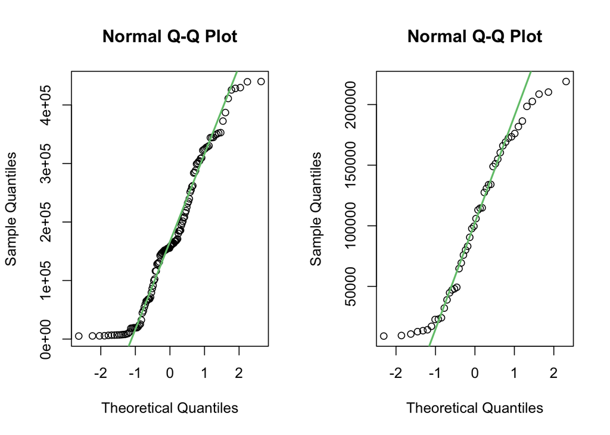

```r
par(mfrow = c(1, 2))
qqnorm(hourly_ridership$total_ridership[hourly_ridership$day_type == "Weekday"])
qqline(hourly_ridership$total_ridership[hourly_ridership$day_type == "Weekday"], col = "#72C47A", lwd = 2)
qqnorm(hourly_ridership$total_ridership[hourly_ridership$day_type == "Weekend"])
qqline(hourly_ridership$total_ridership[hourly_ridership$day_type == "Weekend"], col = "#72C47A", lwd = 2)
```

```r
# t-test for weekday vs. weekend means
weekday_weekend_test <- t.test(total_ridership ~ day_type, data = hourly_ridership)
weekday_weekend_test
```

```
##
##  Welch Two Sample t-test
##
## data:  total_ridership by day_type
## t = 4.641, df = 152.69, p-value = 7.411e-06
## alternative hypothesis: true difference in means between group Weekday and group Weekend is not equal to 0
## 95 percent confidence interval:
##  39700.86 98553.65
## sample estimates:
## mean in group Weekday mean in group Weekend
##              171883.8              102756.6
```

At the $\alpha$ = 0.05 level, the test produced a T statistic of 4.641 with 152.69 degrees of freedom. The associated p-value was 7.411 x 10-6, which allows for the rejection of the null hypothesis. This means that there is sufficient evidence to conclude that the mean hourly ridership on weekdays is significantly different than the mean hourly ridership on weekends.

When looking at the other associated output from the t-test, we can also see that the mean hourly ridership during weekdays is 171883.8 riders per hour and the mean hourly ridership on weekends is 102756.6 riders per hour. We are also 95% confident that the difference in mean hourly ridership between weekdays and weekends is between 39700.86 and 98553.65 riders per hour.

**ANOVA: Differences in mean hourly ridership between time-of-day categories**

A one way ANOVA test was performed to determine if there were differences between the hourly ridership means during different time-of-day categories. Given our findings from the EDA section, we created four time-of-day categories to put our data in. Observations fell during the morning (5:00 AM - 10:59 AM), mid-day (11:00 AM - 3:59 PM), the evening (4:00 PM - 8:59 PM), or the night (9:00 PM - 4:59 AM).

The null hypothesis for this test states that the mean hourly ridership is equal for the morning, mid-day, evening, and night periods. The alternative hypothesis states that at least one time-of-day category has a different mean hourly ridership from the other categories.

Before the test was conducted, a check on the ANOVA assumptions was done. Given the assumptions of normality, independence of errors, and homogeneity of variances, there is concern for violation on all three of them. The QQ plots for each time-of-day category show some deviation from the normal distribution, but the sample sizes for each category are large enough for the test to be robust. The output from Levene’s test showed evidence of heteroscedasticity, and our sample was also not selected at random which could violate the independence of errors. These potential violations may be a limitation of this test. Despite these concerns, we decided to continue evaluating with the one way ANOVA test.

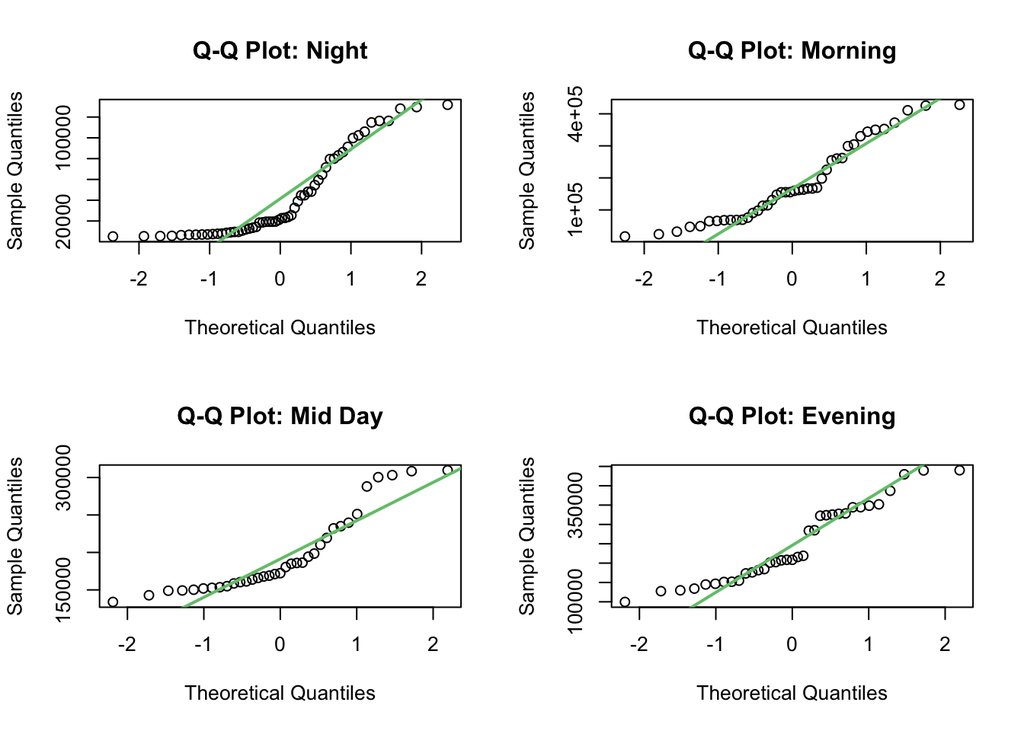

```r
# Assumptions check
par(mfrow = c(2, 2))
for (time_category in unique(hourly_ridership$time_of_day)) {
  x <- hourly_ridership$total_ridership[hourly_ridership$time_of_day == time_category]
  qqnorm(x, main = paste("Q-Q Plot:", time_category))
  qqline(x, col = "#72C47A", lwd = 2)
}
```

```r
leveneTest(total_ridership ~ time_of_day, data = hourly_ridership)
```

```
## Levene's Test for Homogeneity of Variance (center = median)
##        Df F value    Pr(>F)
## group   3   14.37 2.338e-08 ***
##       164
## ---
## Signif. codes:  0 '***' 0.001 '**' 0.01 '*' 0.05 '.' 0.1 ' ' 1
```

```r
# One way ANOVA test and post hoc
time_anova <- aov(total_ridership ~ time_of_day, data = hourly_ridership)
summary(time_anova)
```

```
##              Df    Sum Sq   Mean Sq F value Pr(>F)
## time_of_day   3 1.101e+12 3.671e+11   53.72 <2e-16 ***
## Residuals   164 1.121e+12 6.833e+09
## ---
## Signif. codes:  0 '***' 0.001 '**' 0.01 '*' 0.05 '.' 0.1 ' ' 1
```

```r
time_post_hoc <- TukeyHSD(time_anova)
time_post_hoc
```

```
##   Tukey multiple comparisons of means
##     95% family-wise confidence level
##
## Fit: aov(formula = total_ridership ~ time_of_day, data = hourly_ridership)
##
## $time_of_day
##                       diff        lwr         upr     p adj
## Mid Day-Evening  -52696.43 -103984.46   -1408.397 0.0415268
## Morning-Evening  -67218.61 -116323.16  -18114.058 0.0027759
## Night-Evening   -206050.59 -252280.99 -159820.179 0.0000000
## Morning-Mid Day  -14522.18  -63626.73   34582.371 0.8689305
## Night-Mid Day   -153354.16 -199584.56 -107123.750 0.0000000
## Night-Morning   -138831.98 -182627.47  -95036.482 0.0000000
```

At the $\alpha$ = 0.05 level, the test produced an F statistic 53.72 with an associated p-value of less than 2 x 10-16. Since the p-value is very small and below the alpha level, there is sufficient evidence to reject the null hypothesis. This means that we can conclude that there is at least one time-of-day category that has a different mean hourly ridership from the others.

Given that the ANOVA test was statistically significant, we continued onto a post hoc Tukey test that will evaluate the differences between all time-of-day pairings. After running the post hoc analysis, the time period pairings that showed a statistically significant difference were mid-day and evening, morning and evening, night and evening, night and mid-day, and night and morning. Out of these, we found that the differences between mid-day/evening and morning/evening were notable since they include commute periods. We expected the night period to be significantly different from all of the others due to it including the middle of the night.

**ANOVA: Differences in mean daily ridership between boroughs**

A one way ANOVA test was conducted to analyze the differences in mean daily ridership between boroughs. Since our data included the four boroughs of Manhattan, Brooklyn, the Bronx, and Queens, those were the only potential differences that were tested for.

The null hypothesis for this test states that the mean daily ridership in Manhattan, Brooklyn, the Bronx, and Queens are all equal to each other. The alternative hypothesis states that at least one borough has a different mean daily ridership than the other boroughs.

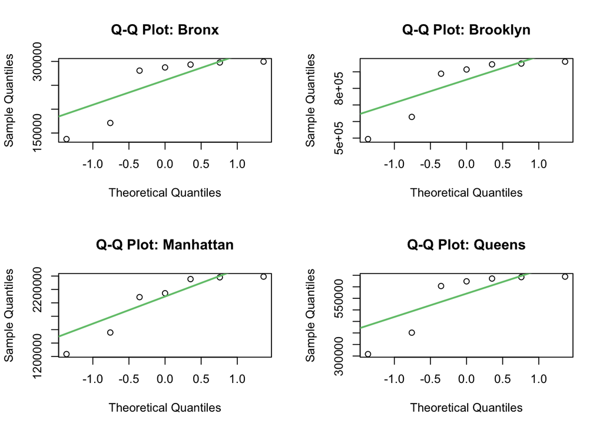

```r
# Daily ridership total for each borough
borough_daily <- project %>%
  mutate(date = as.Date(timestamp)) %>%
  group_by(date, borough) %>%
  summarize(total_ridership = sum(ridership, na.rm = TRUE), .groups = "drop")

# Assumptions check
par(mfrow = c(2, 2))
for (b in unique(borough_daily$borough)) {
  x <- borough_daily$total_ridership[borough_daily$borough == b]
  qqnorm(x, main = paste("Q-Q Plot:", b))
  qqline(x, col = "#72C47A", lwd = 2)
}
```

```r
leveneTest(total_ridership ~ borough, data = borough_daily)
```

```
## Levene's Test for Homogeneity of Variance (center = median)
##       Df F value  Pr(>F)
## group  3  2.8461 0.05885 .
##       24
## ---
## Signif. codes:  0 '***' 0.001 '**' 0.01 '*' 0.05 '.' 0.1 ' ' 1
```

```r
# One way ANOVA test: Do daily averages in each borough differ?
borough_anova <- aov(total_ridership ~ borough, data = borough_daily)
summary(borough_anova)
```

```
##             Df    Sum Sq   Mean Sq F value   Pr(>F)
## borough      3 1.262e+13 4.208e+12   63.86 1.38e-11 ***
## Residuals   24 1.581e+12 6.589e+10
## ---
## Signif. codes:  0 '***' 0.001 '**' 0.01 '*' 0.05 '.' 0.1 ' ' 1
```

```r
# Post hoc tests
borough_post_hoc <- TukeyHSD(borough_anova)
borough_post_hoc
```

```
##   Tukey multiple comparisons of means
##     95% family-wise confidence level
##
## Fit: aov(formula = total_ridership ~ borough, data = borough_daily)
##
## $borough
##                          diff         lwr        upr     p adj
## Brooklyn-Bronx       573430.0   194933.82   951926.2 0.0017792
## Manhattan-Bronx     1768942.0  1390445.82  2147438.2 0.0000000
## Queens-Bronx         298801.9   -79694.32   677298.0 0.1581908
## Manhattan-Brooklyn  1195512.0   817015.82  1574008.2 0.0000000
## Queens-Brooklyn     -274628.1  -653124.32   103868.0 0.2153342
## Queens-Manhattan   -1470140.1 -1848636.32 -1091644.0 0.0000000
```

At the $\alpha$ = 0.05 level, the test produced an F value of 63.86 with the associated p-value of 1.38 x 10-11. Due to this p-value being smaller than the alpha level, there is sufficient evidence to reject the null hypothesis. This means that we are able to conclude that at least one borough has a different mean daily ridership than the other boroughs.

Given that the null hypothesis was rejected in the initial ANOVA test, we continued on to conduct a post hoc Tukey test. After running the Tukey test, we found that the borough pairings that had significantly different mean daily ridership values were Brooklyn and the Bronx, Manhattan and the Bronx, Manhattan and Brooklyn, and Queens and Manhattan. From these results, we are able to see that Manhattan’s mean daily ridership differs significantly from all other boroughs.

# Bus-to-Subway Transfers

```r
project %>%
  group_by(station_complex, station_complex_id) %>%
  summarize(
    total_transfers = sum(transfers, na.rm = TRUE),
    average_transfers = mean(transfers, na.rm = TRUE),
    observations = n()
  ) %>%
  arrange(desc(total_transfers))
```

[output not shown]

```
## # A tibble: 424 × 5
## # Groups:   station_complex [424]
##    station_complex          station_complex_id total_transfers average_transfers
##    <chr>                                 <int>           <dbl>             <dbl>
##  1 Flushing-Main St (7)                    447           72276             44.9
##  2 Jamaica Center-Parsons/…                278           39801             26.1
##  3 Kew Gardens-Union Tpke …                259           28726             18.6
##  4 74-Broadway (7)/Jackson…                616           27347             16.8
##  5 Jamaica-179 St (F)                      254           25531             17.2
##  6 Lexington Av (N,R,W)/59…                613           17435             11.3
##  7 South Ferry (1)/Whiteha…                635           16319             10.6
##  8 Forest Hills-71 Av (E,F…                261           15453              9.90
##  9 161 St-Yankee Stadium (…                604           15017              9.60
## 10 Flatbush Av-Brooklyn Co…                359           14005              9.42
## # ℹ 414 more rows
## # ℹ 1 more variable: observations <int>
```

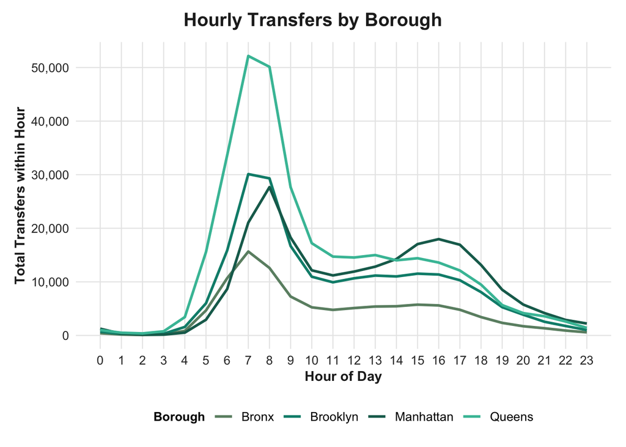

```r
hourly_transfers_total <- project %>%
  group_by(hour, borough) %>%
  summarize(total_hourly_transfers = sum(transfers, na.rm = TRUE),
  .groups = "drop"
)

ggplot(hourly_transfers_total, aes(x = hour, y = total_hourly_transfers, color = borough)) + geom_line(lwd = 1) +
  scale_x_continuous(
    breaks = 0:23, #To have all the hours displayed
  ) +
  scale_y_continuous(labels = scales::comma)+
  scale_color_manual(values = c(
    "Bronx" = "#6B8E72",
    "Brooklyn" = "#008C7A",
    "Manhattan" = "#176B5B",
    "Queens" = "#42BFA5"
  )) +
  labs(
  title = "Hourly Transfers by Borough",
  x = "Hour of Day",
  y = "Total Transfers within Hour",
  color = "Borough"
)+
  theme_mygraphs()
```

All boroughs demonstrate a higher amount of total bus-to-subway transfers during the morning hours. Queens clearly shows the highest number of total transfers, while Manhattan has a noticeable bimodal distribution, indicating people take the bus to the subway during the morning and evening time periods.

**Where are the top ten stations for bus transfers?**

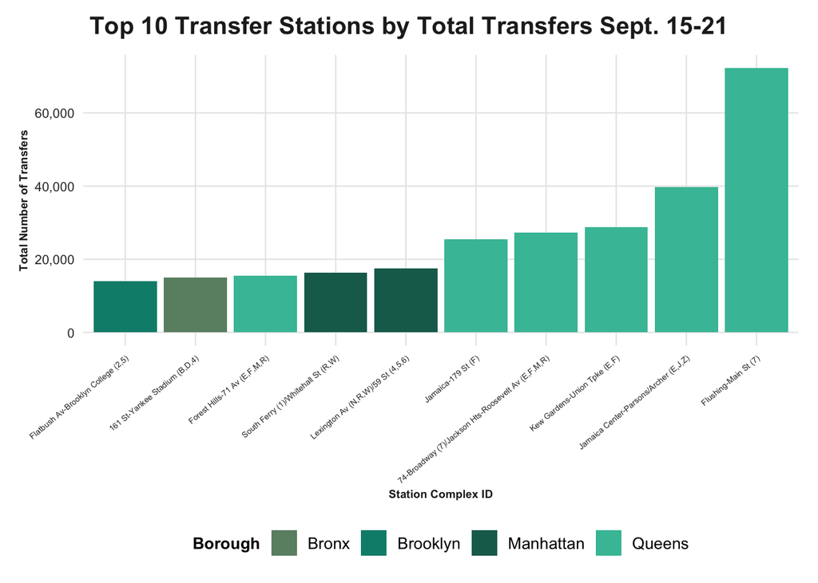

```r
top_transfer_stations <- project %>%
  group_by(station_complex, borough) %>%
  summarize(
    total_transfers = sum(transfers, na.rm = TRUE),
    .groups = "drop"
  ) %>%
  arrange(desc(total_transfers)) %>%
  slice_head(n = 10)

ggplot(top_transfer_stations, aes(x = reorder(station_complex, total_transfers), y = total_transfers, fill = borough)) + geom_col() + scale_fill_manual(values = c(
  "Bronx" = "#6B8E72",
  "Brooklyn" = "#008C7A",
  "Manhattan" = "#176B5B",
  "Queens" = "#42BFA5"
)) +
  scale_y_continuous(labels = scales::comma) +
  labs(
  title = "Top 10 Transfer Stations by Total Transfers Sept. 15-21",
  x = "Station Complex ID",
  y = "Total Number of Transfers",
  fill = "Borough"
) +
  theme_mygraphs()+
  theme(
  axis.text.x = element_text(
    angle = 40,
    hjust = 1,
    vjust = 1,
    size = 5
  ),
  axis.text.y = element_text(size = 8),
  axis.title.x = element_text(size = 7),
  axis.title.y = element_text(size = 7)
)
```

The top five transfer stations for total number of bus-to-subway transfers are Flushing-Main St (7), Jamaica Center-Parsons/Archer (E,J,Z), Kew Gardens-Union Tpke (E,F), 74-Broadway (7)/Jackson Hts-Roosevelt Av (E,F,M,R), Jamaica-179 St (F), which are all in Queens. Additionally, Flushing-Main St, Jamaica Center-Parsons/Archer, Jamaica-179 St, South Ferry/Whitehall St in Manhattan, and Flatbush Av-Brooklyn College in Brooklyn are the last subway stations on their respective lines, indicating people may take the bus from areas outside of subway map coverage.

**Sum total transfers at top 10 stations for each hour of each day**

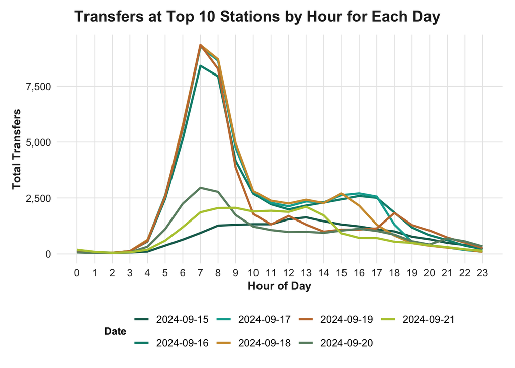

```r
daily_hourly_top_transfers <- project %>%
  filter(station_complex %in% top_transfer_stations$station_complex) %>%
  mutate(date = as.Date(timestamp)) %>%
  group_by(date, hour) %>%
  summarize(
    total_transfers = sum(transfers, na.rm = TRUE),
    .groups = "drop"
  )
# Line graph of daily total transfers by hour at top 10 systems
ggplot(
  daily_hourly_top_transfers,
  aes(
    x = hour,
    y = total_transfers,
    color = factor(date),
    group = date
  )
) +
  geom_line(linewidth = 1) +
  scale_x_continuous(
    breaks = 0:23
  ) +
  scale_y_continuous(labels = scales::comma) + #Adds commas to the numbers on the axis
scale_color_manual(
  values = c(
    "#176B5B",  # Dark teal
    "#008C7A",  # Teal
    "#00A99D",  # Turquoise
    "#D09A3A",  # Muted gold
    "#C47A3C",  # Light brown
    "#6B8E72",  # Sage
    "#B5C83E"   # Yellow green
  )
)+
  labs(
    title = "Transfers at Top 10 Stations by Hour for Each Day",
    x = "Hour of Day",
    y = "Total Transfers",
    color = "Date"
  ) +
  theme_mygraphs()
```

Of the top 10 stations, bus-to-subway transfers during the morning commute are clear on Monday (Sept. 16) to Thursday (Sept. 19). There is a slight curve on Friday (Sept. 20); however, this line is more similar to the Saturday and Sunday lines (Sept. 21 and 15, respectively). This supports that there are differences in morning commuting hours compared to the same time period during the weekend. Additionally, hybrid jobs may allow employees to work remotely on Fridays more often than Monday through Thursday.

**Distribution of transfers at top 10 stations by hour**

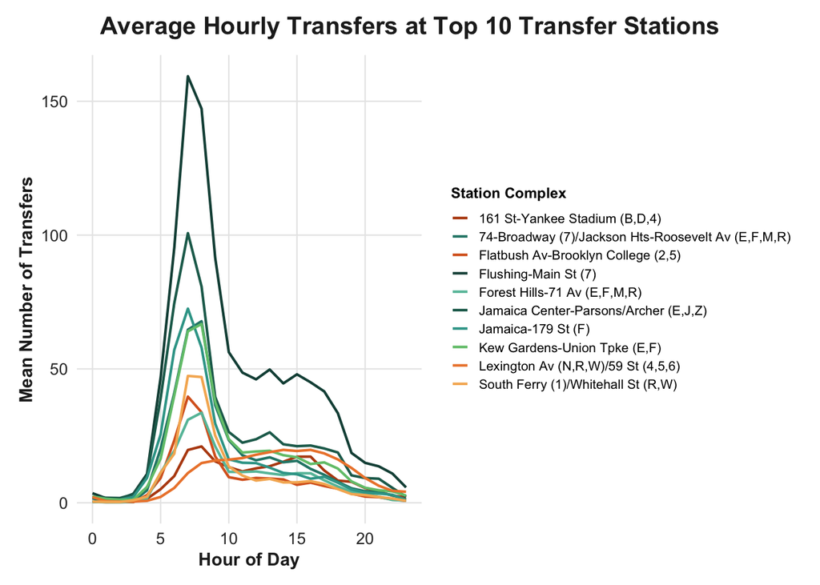

```r
hourly_transfers <- project %>%
  semi_join(
    top_transfer_stations,
    by = c("station_complex")
  ) %>%
  group_by(station_complex, hour) %>%
  summarize(
    mean_transfers = mean(transfers, na.rm = TRUE),
    .groups = "drop"
  )
ggplot(hourly_transfers, aes(x = hour, y = mean_transfers, color = factor(station_complex), group = station_complex)) + geom_line(linewidth = .75) +
  scale_color_manual(
  values = c(
    "#B84A12",  # Yankee
    "#288577",  # 74 Broadway
    "#D96524",  # Flatbush
    "#164E45",  # Flushing
    "#65BFA8",  # Forest Hills-71 Ave
    "#1F6B5B",  # Jamaica Center
    "#36A397",  # Jamaica - 179 St
    "#72C47A",  # Kew Gardens
    "#ED8538",  # Lexington Ave
    "#F5B461"   # South Ferry
  )) +
  labs(
    title = "Average Hourly Transfers at Top 10 Transfer Stations",
    x = "Hour of Day",
    y = "Mean Number of Transfers",
    color = "Station Complex"
  )+
  theme_mygraphs() +
  theme(
  legend.position = "right",
  legend.text = element_text(size = 8),
  legend.title = element_text(size = 9),
  legend.key.size = unit(0.4, "cm")
)
```

Flushing-Main St. Station shows an elevated transfer rate through the day and evening.

**Weekend vs Weekday Hourly Transfers at All Stations**

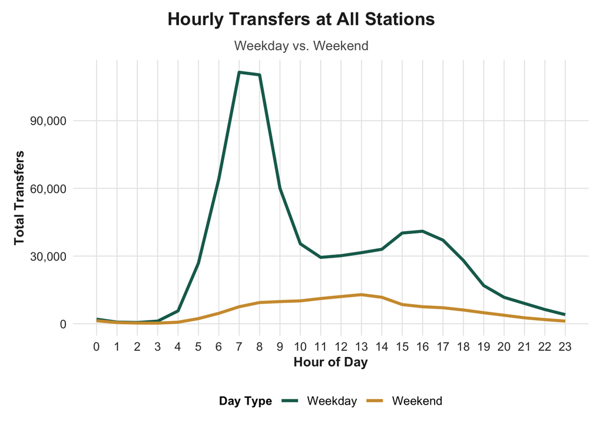

```r
hourly_transfers <- project %>%
  mutate(
    hour = hour(timestamp),
    day_type = if_else(
      wday(timestamp) %in% c(1, 7),
      "Weekend",
      "Weekday"
    )
  ) %>%
  group_by(day_type, hour) %>%
  summarize(
    total_transfers = sum(transfers, na.rm = TRUE),
    .groups = "drop"
  )
ggplot(
  hourly_transfers,
  aes(
    x = hour,
    y = total_transfers,
    color = day_type,
    group = day_type
  )
) +
  geom_line(linewidth = 1.2) +
  scale_color_manual(
    values = c(
      "Weekday" = "#176B5B",
      "Weekend" = "#D09A3A"
    )
  ) +
  scale_x_continuous(
    breaks = 0:23,
  ) +
  scale_y_continuous(
    labels = scales::comma
  ) +
  labs(
    title = "Hourly Transfers at All Stations",
    subtitle = "Weekday vs. Weekend",
    x = "Hour of Day",
    y = "Total Transfers",
    color = "Day Type"
  ) +
  theme_mygraphs()
```

Similar to the Top 10 Subway Stations comparison, there’s a clear difference between weekend and weekday bus-to-subway transfers. Additionally, there is once again a clear increase in the number of people using buses to transfer at subway stations during the morning weekday commute times in comparison to the evening commute times.

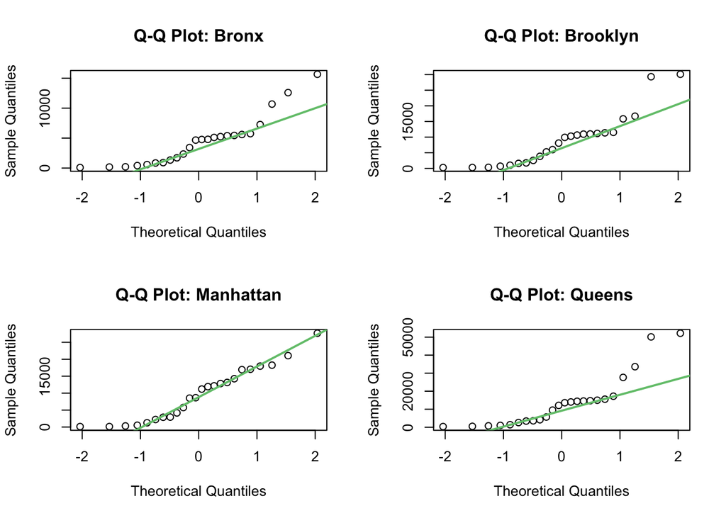

```r
hourly_transfers_total <- project %>%
  group_by(hour, borough) %>%
  summarize(total_hourly_transfers = sum(transfers, na.rm = TRUE),
  .groups = "drop"
)
boroughs <- unique(hourly_transfers_total$borough)
par(mfrow = c(2,2))

for (b in boroughs) {
  borough_data <- hourly_transfers_total$total_hourly_transfers[
    hourly_transfers_total$borough == b
  ]

  qqnorm(borough_data,
         main = paste("Q-Q Plot:", b),
         xlab = "Theoretical Quantiles",
         ylab = "Sample Quantiles")

  qqline(borough_data, col = "#72C47A", lwd = 2)
}
```

```r
par(mfrow = c(1, 1))
```

**Hypothesis Testing of Transfers**

Our primary questions of interest regarding transfers are whether there is a normal distribution of bus-to-subway transfers during 1) commuting periods vs non-commuting periods and 2) during weekdays vs weekends. Additionally, are transfer amounts the same during commuting periods vs non-commuting periods as well as during the week in comparison to the weekend.

**T-Tests: Commute vs. Non-commute; Weekday vs. Weekend**

```r
hourly_transfers <- project %>%
  mutate(commute_period = if_else(commute_type %in% c("Morning Commute", "Evening Commute"), "Commute","Non-Commute")) %>%
  group_by(timestamp, day_type, time_of_day, commute_period) %>%
  summarize(total_transfers = sum(transfers, na.rm = TRUE), .groups = "drop")

hourly_transfers
```

```
## # A tibble: 168 × 5
##    timestamp           day_type time_of_day commute_period total_transfers
##    <dttm>              <fct>    <fct>       <chr>                    <dbl>
##  1 2024-09-15 00:00:00 Weekend  Night       Non-Commute                594
##  2 2024-09-15 01:00:00 Weekend  Night       Non-Commute                279
##  3 2024-09-15 02:00:00 Weekend  Night       Non-Commute                170
##  4 2024-09-15 03:00:00 Weekend  Night       Non-Commute                143
##  5 2024-09-15 04:00:00 Weekend  Night       Non-Commute                283
##  6 2024-09-15 05:00:00 Weekend  Morning     Non-Commute                856
##  7 2024-09-15 06:00:00 Weekend  Morning     Non-Commute               1693
##  8 2024-09-15 07:00:00 Weekend  Morning     Non-Commute               2723
##  9 2024-09-15 08:00:00 Weekend  Morning     Non-Commute               3622
## 10 2024-09-15 09:00:00 Weekend  Morning     Non-Commute               4005
## # ℹ 158 more rows
```

Commute vs. Non-commute time periods:

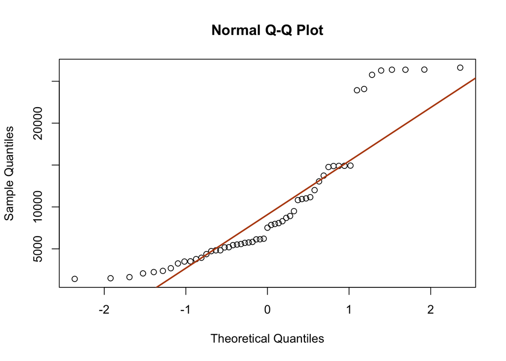

```r
qqnorm(hourly_transfers$total_transfers[hourly_transfers$commute_period == "Commute"])
qqline(hourly_transfers$total_transfers[hourly_transfers$commute_period == "Commute"], col = "#B84A12", lwd = 2)
```

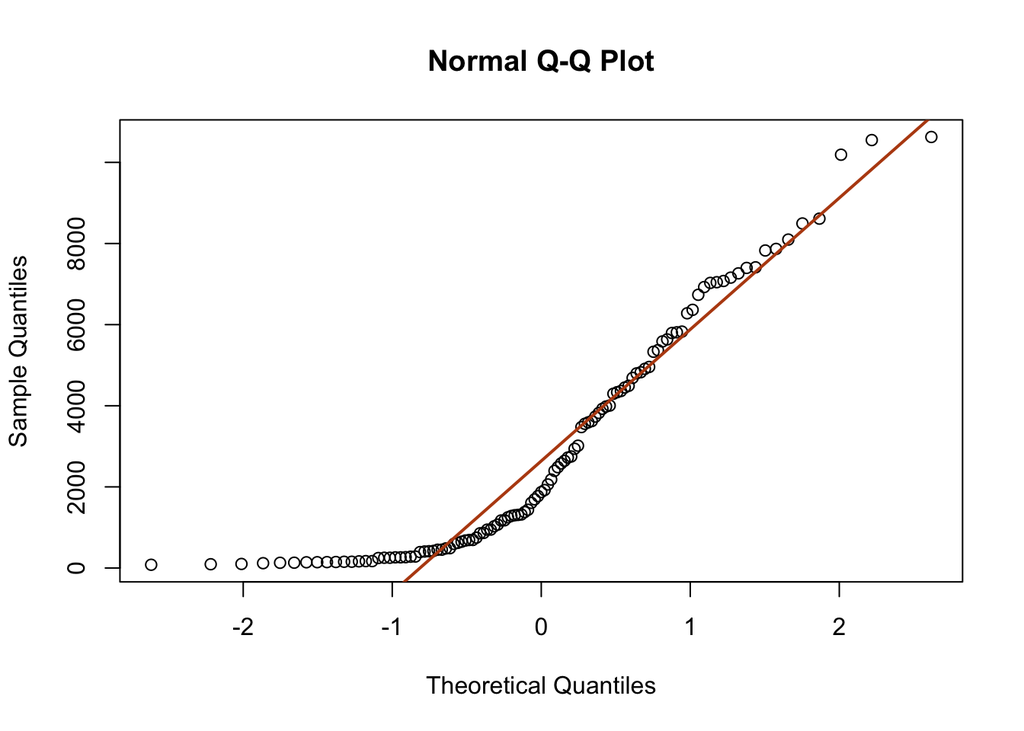

```r
qqnorm(hourly_transfers$total_transfers[hourly_transfers$commute_period == "Non-Commute"])
qqline(hourly_transfers$total_transfers[hourly_transfers$commute_period == "Non-Commute"], col = "#B84A12", lwd = 2)
```

Non-commute transfers have a more normal distribution than transfers during commuting hours, but both time periods have extreme values.

Weekday vs. Weekend periods:

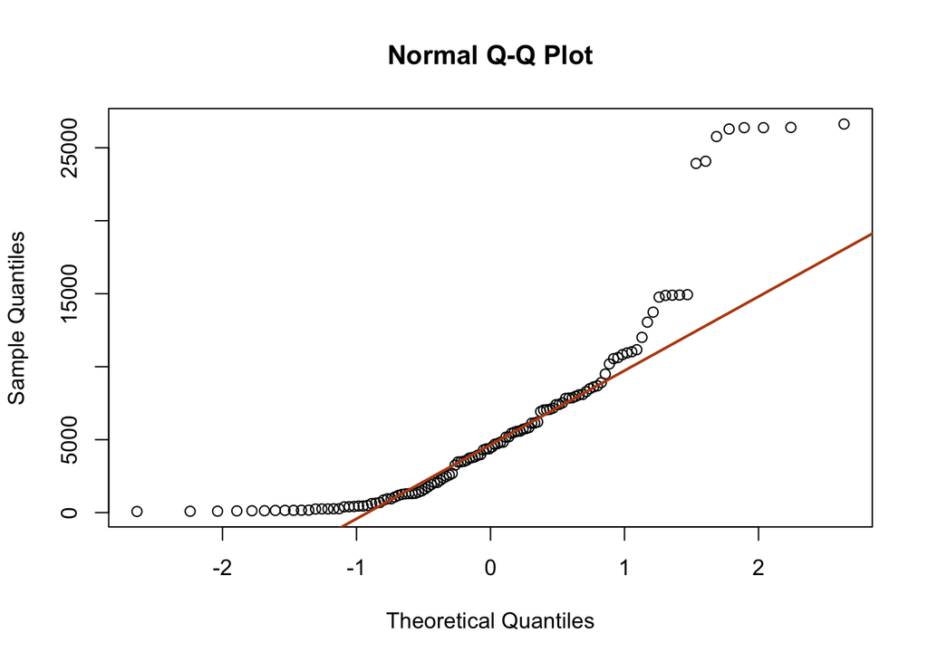

```r
qqnorm(hourly_transfers$total_transfers[hourly_transfers$day_type == "Weekday"])
qqline(hourly_transfers$total_transfers[hourly_transfers$day_type == "Weekday"], col = "#B84A12", lwd = 2)
```

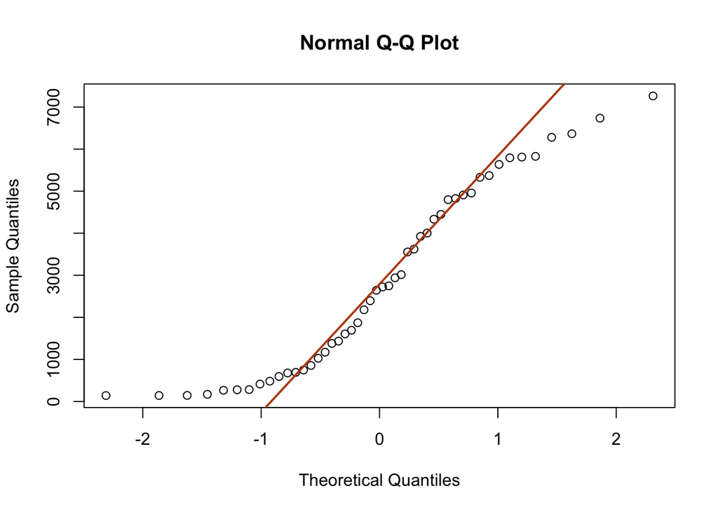

```r
qqnorm(hourly_transfers$total_transfers[hourly_transfers$day_type == "Weekend"])
qqline(hourly_transfers$total_transfers[hourly_transfers$day_type == "Weekend"], col = "#B84A12", lwd = 2)
```

Both distributions of transfers during the weekend and weekday are not normal, as evidenced by the extreme values and limited adherence to the Q-Q plot line.

Assumptions for T-Tests: For the t-tests evaluating commuting time periods and weekend vs. weekday transfer amounts, we assumed the sample size was large enough to be robust against normality violations. Additionally, the population standard deviation is unknown, ruling out the z-test. While the independent observation assumption may be violated due to time data, the t-test is preferred for this class.

```r
# t-test for commute time vs. non-commute time means
commute_period_test <- t.test(total_transfers ~ commute_period, data = hourly_transfers)
commute_period_test
```

```
##
##  Welch Two Sample t-test
##
## data:  total_transfers by commute_period
## t = 6.5301, df = 61.313, p-value = 1.449e-08
## alternative hypothesis: true difference in means between group Commute and group Non-Commute is not equal to 0
## 95 percent confidence interval:
##  4808.953 9053.408
## sample estimates:
##     mean in group Commute mean in group Non-Commute
##                  9873.127                  2941.947
```

Null hypothesis: Mean hourly transfers of commute periods = Mean hourly transfers of non-commute periods

Alternative hypothesis: Mean hourly transfers of commute periods ≠ Mean hourly transfers of non-commute periods

Alpha = 0.05 > P-value = 1e-08 –> Reject the null hypothesis. There is sufficient evidence to conclude that the mean hourly transfer amounts during commute periods are different from the mean hourly transfer amounts during non-commute periods

```r
# t-test for weekday vs. weekend means
weekday_weekend_test <- t.test(total_transfers ~ day_type, data = hourly_transfers)
weekday_weekend_test
```

```
##
##  Welch Two Sample t-test
##
## data:  total_transfers by day_type
## t = 4.7669, df = 162.5, p-value = 4.129e-06
## alternative hypothesis: true difference in means between group Weekday and group Weekend is not equal to 0
## 95 percent confidence interval:
##  1906.726 4603.624
## sample estimates:
## mean in group Weekday mean in group Weekend
##              6141.133              2885.958
```

Null hypothesis: Mean hourly transfers on weekdays = Mean hourly transfers on weekends

Alternative hypothesis: Mean hourly transfers on weekdays ≠ Mean hourly transfers on weekends

Alpha = 0.05 > P-value = 4e-06 –> Reject the null hypothesis. There is sufficient evidence to conclude that the mean hourly ridership on weekdays is different from the mean hourly ridership on weekends

# Conclusions

**Key Takeaways**

Based on the EDA and analysis that was performed on this dataset, we were able to make some conclusions regarding subway ridership in New York City during the week of September 15-21, 2024. We found that many factors can influence the demand of subway ridership, such as time of day, type of day (weekdays vs. weekends), and borough. Specifically, we found that ridership varies throughout the day with commute versus non-commute periods. This is consistent with the expected commuting behavior that we hypothesized before running the analysis. We were also able to see that ridership varies by borough. Lastly, we were able to conclude that a lot of the transfer activity is concentrated in Queens, which makes sense because of the population that commutes into the city to work from Long Island.

**Limitations**

Even though we were able to draw conclusions after analyzing our data, it is important to note that there are some limitations to the analysis. First, many of the hypothesis test assumptions were not strongly satisfied at times. There may be better statistical tests to run on our data, but we stayed with t-tests and ANOVA tests because they are the tools that we know. Additionally, it is unclear if potential construction and/or closures in the subway system affected our data for the chosen week. This is not something that we were able to explore in the data, but it is a possibility that there could have been some effects from this. The data also only captures riders that pay at the turnstile when coming into the station, so ridership for individuals who do not pay was not able to be captured. Lastly, the findings from our analysis are the most generalizable to the specific week of September 15-21, 2024. Further analysis could be done during a range of different or longer time periods to consider results that may be more generalizable.